# Konicek_homework_2

kelli

2025-01-30

### Libraries

```r
library(tidyverse)
library(here)
library(emmeans)
library(ggeffects)
library(GGally)
library(effects)
library(ggResidpanel)
library(car)
#install.packages('emmeans')
```

### Data

```r
raw <- read_csv(here("week_2", "data","leibold_mesocosm_data_subset.csv"))

#turn blocks into a factor
raw$Block <- as.factor(raw$Block)
raw$NutrientLevel <- as.factor(raw$NutrientLevel)
raw$FoodWeb <- as.factor(raw$FoodWeb)
```

## 1)

*Create a linear model that tests whether richness is explained by nutrient level and/or food web treatment, and whether the effect of food web treatment differs between nutrient levels, while also accounting for the blocked structure of the experiment.*

```r
# Model
richness.lm <- lm(Phyto_Chao1 ~ NutrientLevel*FoodWeb + Block, data = raw)
#Summary
summary(richness.lm)
```

```
##
## Call:
## lm(formula = Phyto_Chao1 ~ NutrientLevel * FoodWeb + Block, data = raw)
##
## Residuals:
##     Min      1Q  Median      3Q     Max
## -7.9575 -3.1031  0.1463  2.2300  9.2563
##
## Coefficients:
##                         Estimate Std. Error t value Pr(>|t|)
## (Intercept)              10.7437     2.3171   4.637 6.48e-05 ***
## NutrientLevelL            2.3912     2.6524   0.902   0.3745
## FoodWebG                  6.1100     2.6524   2.304   0.0284 *
## FoodWebP                 -0.3990     2.9133  -0.137   0.8920
## Block2                   -0.1676     2.1969  -0.076   0.9397
## Block3                   -0.9499     2.1048  -0.451   0.6550
## Block4                   -1.6725     2.3149  -0.722   0.4756
## NutrientLevelL:FoodWebG   0.7125     3.7948   0.188   0.8523
## NutrientLevelL:FoodWebP   5.1877     3.9864   1.301   0.2030
## ---
## Signif. codes:  0 '***' 0.001 '**' 0.01 '*' 0.05 '.' 0.1 ' ' 1
##
## Residual standard error: 4.885 on 30 degrees of freedom
## Multiple R-squared:  0.4046, Adjusted R-squared:  0.2458
## F-statistic: 2.548 on 8 and 30 DF,  p-value: 0.03008
```

```r
#Fstat
Anova(richness.lm)
```

```
## Anova Table (Type II tests)
##
## Response: Phyto_Chao1
##                       Sum Sq Df F value   Pr(>F)
## NutrientLevel         163.07  1  6.8341 0.013853 *
## FoodWeb               314.91  2  6.5985 0.004217 **
## Block                  14.80  3  0.2068 0.890886
## NutrientLevel:FoodWeb  45.82  2  0.9601 0.394315
## Residuals             715.86 30
## ---
## Signif. codes:  0 '***' 0.001 '**' 0.01 '*' 0.05 '.' 0.1 ' ' 1
```

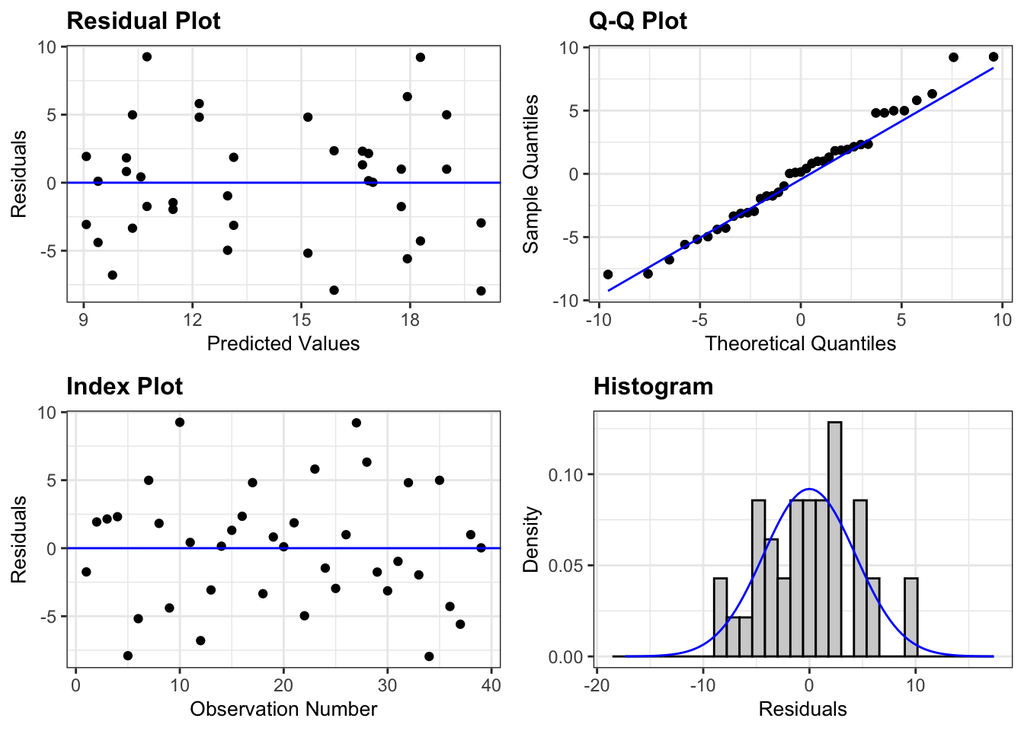

```r
resid_panel(richness.lm)
```

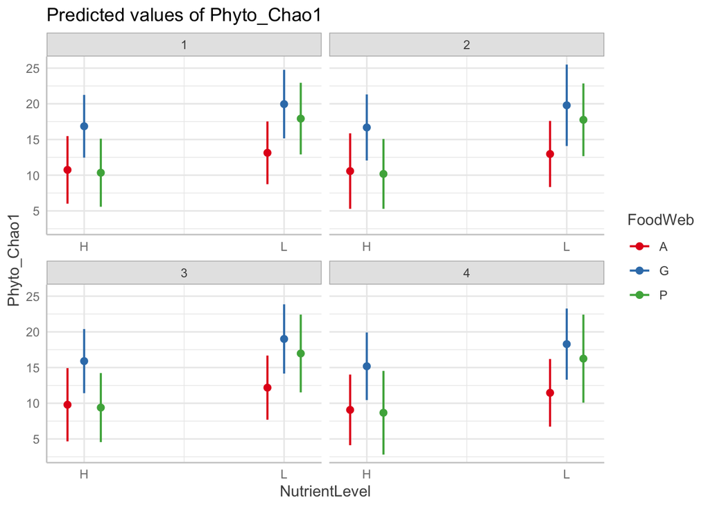

```r
#Effects Plot (?)
plot(ggeffect(richness.lm, terms = c('NutrientLevel','FoodWeb', "Block")))
```

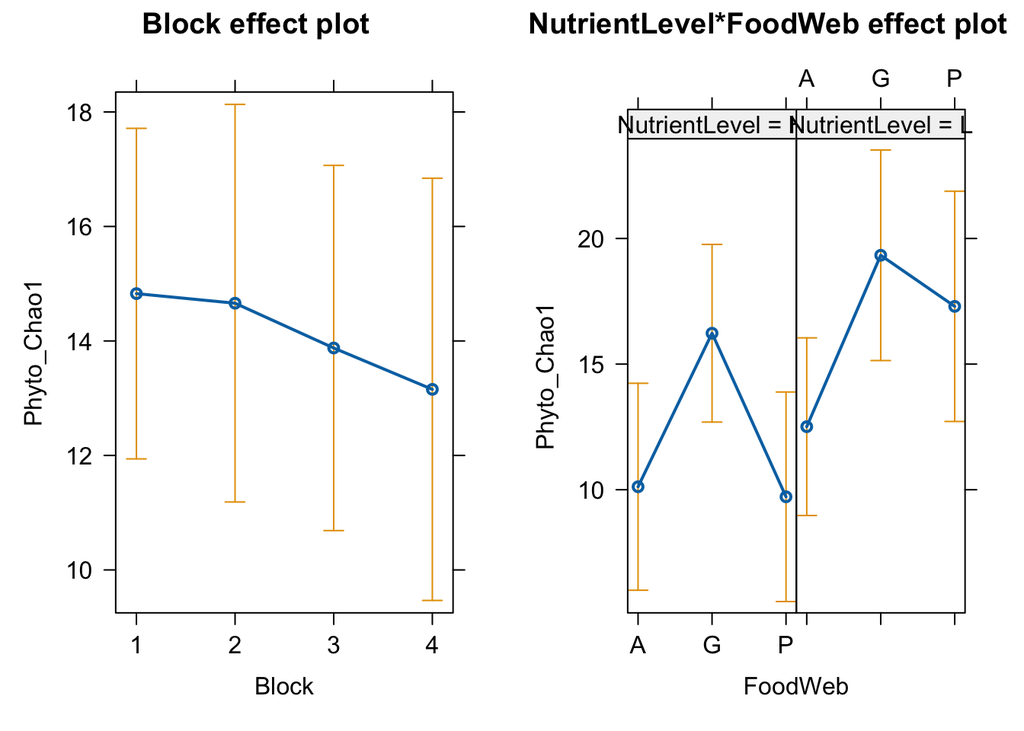

```r
plot(allEffects(richness.lm))
```

Note to me: The higher the F stat relative to the DF, where numerator is the parameters and the demominator is the residuals, the stronger the predictors (Anova) or model (global F) explains the variation.

## 2)

*Why is it important to account for the blocks? Analyze the results of the linear model as we did in Homework 1. What is your interpretation of these results so far?*

It’s important to account for blocks because that can help to explain nonindependent and/or unexplained variation.

Based on looking at the summary and the Anova F-stats for each parameter, it looks like phytoplankton diversity goes up when nutrient levels are lower, and when grazers are introduced to algae without the presence of predators. The residuals also look pretty good, I think, so a linear model is a good fit!

Okay, let’s see if I understand how to interpret the F stats. The global F statistic in the lm summary is F 8,30 = 2.548, p= 0.03008, which means the model can explain variation. The partial F-stat from the Anova shows that the predictors Nutrient Level (F 1, 30 = 6.8341, p= 0.013853) and FoodWeb (F 2, 30 = 6.5985, p=0.004217) significantly explain the variance in the model.

The low F stats for the FoodWeb:Nutrient Level interaction means that the nutrient level doesn’t necessarily effect the independent influence the food web has on phytoplankton diversity, or vice versa.

## 3)

Use contrasts to test hypotheses:  
whether the grazer treatment (G) has greater richness than the algae treatment (A)

```r
algae.graze.contrast <- emmeans(richness.lm, specs = trt.vs.ctrl ~ FoodWeb)
algae.graze.contrast
```

```
## $emmeans
##  FoodWeb emmean   SE df lower.CL upper.CL
##  A         11.2 1.33 30     8.53     14.0
##  G         17.7 1.34 30    14.97     20.4
##  P         13.4 1.57 30    10.23     16.6
##
## Results are averaged over the levels of: NutrientLevel, Block
## Confidence level used: 0.95
##
## $contrasts
##  contrast estimate   SE df t.ratio p.value
##  G - A        6.47 1.88 30   3.448  0.0033
##  P - A        2.19 2.08 30   1.056  0.4790
##
## Results are averaged over the levels of: NutrientLevel, Block
## P value adjustment: dunnettx method for 2 tests
```

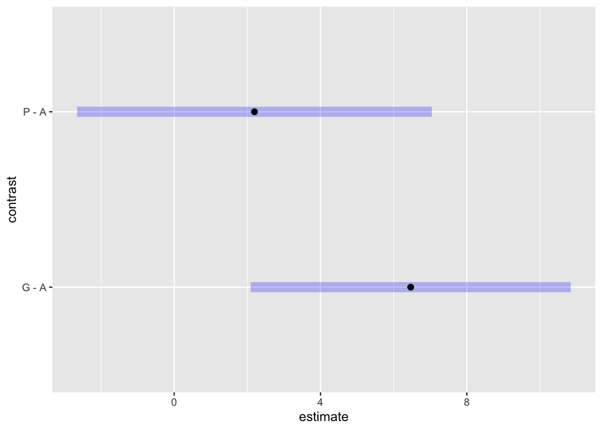

```r
plot(algae.graze.contrast$contrasts)
```

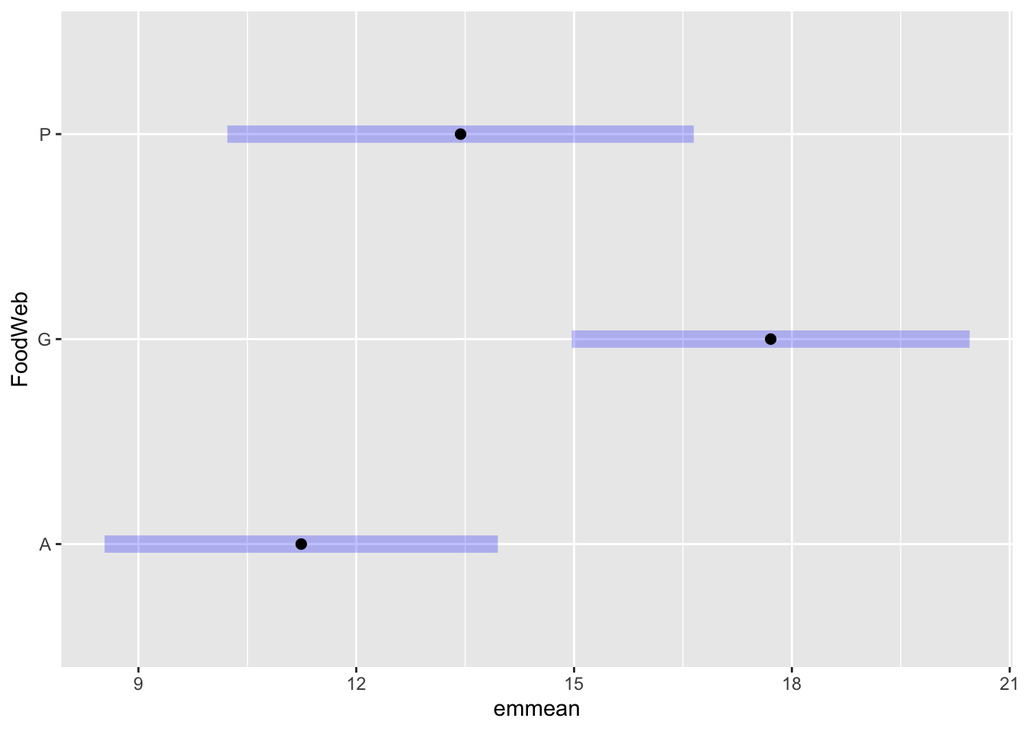

```r
plot(algae.graze.contrast$emmeans)
```

It does! G - A = 6.47 emmeans, adj. p = 0.0033

*whether the effect of grazers differs between high and low nutrient levels (we think the effect of grazers on coexistence may be greater at high nutrient loading)*

```r
nut.contrast <- (emmeans(richness.lm, specs = pairwise ~ NutrientLevel + FoodWeb,
                        at    = list(FoodWeb = c("G"))))
nut.contrast
```

```
## $emmeans
##  NutrientLevel FoodWeb emmean   SE df lower.CL upper.CL
##  H             G         16.2 1.73 30     12.6     19.7
##  L             G         19.3 2.05 30     15.1     23.5
##
## Results are averaged over the levels of: Block
## Confidence level used: 0.95
##
## $contrasts
##  contrast  estimate   SE df t.ratio p.value
##  H G - L G     -3.1 2.68 30  -1.157  0.2565
##
## Results are averaged over the levels of: Block
```

HG - LG is a -3.1 difference with a non-adjusted p value of 0.2565. So Grazers don’t differently effect phytoplankton diversity at H or L nutrient levels.

## 4)

*Use emmeans to calculate the estimated marginal means of each combination of nutrient level and food web treatment*

```r
combo.contrast <- (emmeans(richness.lm, specs = pairwise ~ FoodWeb+NutrientLevel))
combo.contrast
```

```
## $emmeans
##  FoodWeb NutrientLevel emmean   SE df lower.CL upper.CL
##  A       H              10.05 2.01 30     5.94     14.2
##  G       H              16.16 1.73 30    12.63     19.7
##  P       H               9.65 2.06 30     5.44     13.9
##  A       L              12.44 1.73 30     8.91     16.0
##  G       L              19.26 2.05 30    15.07     23.5
##  P       L              17.23 2.26 30    12.61     21.8
##
## Results are averaged over the levels of: Block
## Confidence level used: 0.95
##
## $contrasts
##  contrast  estimate   SE df t.ratio p.value
##  A H - G H   -6.110 2.65 30  -2.304  0.2240
##  A H - P H    0.399 2.91 30   0.137  1.0000
##  A H - A L   -2.391 2.65 30  -0.902  0.9431
##  A H - G L   -9.214 2.85 30  -3.237  0.0318
##  A H - P L   -7.180 3.05 30  -2.353  0.2053
##  G H - P H    6.509 2.69 30   2.421  0.1811
##  G H - A L    3.719 2.44 30   1.523  0.6530
##  G H - G L   -3.104 2.68 30  -1.157  0.8533
##  G H - P L   -1.070 2.84 30  -0.376  0.9989
##  P H - A L   -2.790 2.69 30  -1.038  0.9012
##  P H - G L   -9.613 2.95 30  -3.263  0.0299
##  P H - P L   -7.579 2.97 30  -2.553  0.1410
##  A L - G L   -6.822 2.68 30  -2.543  0.1438
##  A L - P L   -4.789 2.84 30  -1.683  0.5528
##  G L - P L    2.034 3.11 30   0.654  0.9856
##
## Results are averaged over the levels of: Block
## P value adjustment: tukey method for comparing a family of 6 estimates
```

## 5)

*Define contrasts to test:*

*(1) Whether G is different from A in the H treatment:*

```r
H_emmeans <- emmeans(richness.lm,
                        specs = pairwise  ~ FoodWeb|NutrientLevel,
                        at    = list(NutrientLevel = c("H")))
H_emmeans
```

```
## $emmeans
## NutrientLevel = H:
##  FoodWeb emmean   SE df lower.CL upper.CL
##  A        10.05 2.01 30     5.94     14.2
##  G        16.16 1.73 30    12.63     19.7
##  P         9.65 2.06 30     5.44     13.9
##
## Results are averaged over the levels of: Block
## Confidence level used: 0.95
##
## $contrasts
## NutrientLevel = H:
##  contrast estimate   SE df t.ratio p.value
##  A - G      -6.110 2.65 30  -2.304  0.0707
##  A - P       0.399 2.91 30   0.137  0.9897
##  G - P       6.509 2.69 30   2.421  0.0550
##
## Results are averaged over the levels of: Block
## P value adjustment: tukey method for comparing a family of 3 estimates
```

It is different, but the contrast isn’t really significant. A - G -6.110 2.65 30 -2.304 0.0707

If we can judge these relative to each other, the difference between A and G is not as much as, say, G and P for the high treatments. That is not true for the Low, however.

*(2) Whether G is different from A in the L treatment:*

```r
L_emmeans <- emmeans(richness.lm,
                        specs = pairwise ~ FoodWeb | NutrientLevel,
                        at    = list(NutrientLevel = c("L")))
L_emmeans
```

```
## $emmeans
## NutrientLevel = L:
##  FoodWeb emmean   SE df lower.CL upper.CL
##  A         12.4 1.73 30     8.91     16.0
##  G         19.3 2.05 30    15.07     23.5
##  P         17.2 2.26 30    12.61     21.8
##
## Results are averaged over the levels of: Block
## Confidence level used: 0.95
##
## $contrasts
## NutrientLevel = L:
##  contrast estimate   SE df t.ratio p.value
##  A - G       -6.82 2.68 30  -2.543  0.0421
##  A - P       -4.79 2.84 30  -1.683  0.2281
##  G - P        2.03 3.11 30   0.654  0.7917
##
## Results are averaged over the levels of: Block
## P value adjustment: tukey method for comparing a family of 3 estimates
```

A - G -6.822 2.68 30 -2.543 0.0421

A-G is different!

*(3) whether G is different from A when averaging the H and L treatments:*

```r
avg.emmeans <- pairs(emmeans(richness.lm,"FoodWeb"))
avg.emmeans
```

```
##  contrast estimate   SE df t.ratio p.value
##  A - G       -6.47 1.88 30  -3.448  0.0047
##  A - P       -2.19 2.08 30  -1.056  0.5480
##  G - P        4.27 2.10 30   2.033  0.1217
##
## Results are averaged over the levels of: NutrientLevel, Block
## P value adjustment: tukey method for comparing a family of 3 estimates
```

I think I did this right, but I also don’t know how to get “Block” out of the averages. Maybe that’s ok though? Anyway, when averaging the Nutritent Levels in, G is different from A (A-G= -6.47, adj. p= 0.0047). They are different.

*(4) Define an interaction contrast that tests whether the difference between G and A is itself different between H and L (is G-A for the high nutrient treatments greater or smaller than G-A for the low nutrient treatments?)*

```r
levels.contrast <- (emmeans(richness.lm,
                            specs = pairwise ~ FoodWeb*NutrientLevel,
                            at    = list(FoodWeb = c("G","A"))))
levels.contrast
```

```
## $emmeans
##  FoodWeb NutrientLevel emmean   SE df lower.CL upper.CL
##  G       H               16.2 1.73 30    12.63     19.7
##  A       H               10.0 2.01 30     5.94     14.2
##  G       L               19.3 2.05 30    15.07     23.5
##  A       L               12.4 1.73 30     8.91     16.0
##
## Results are averaged over the levels of: Block
## Confidence level used: 0.95
##
## $contrasts
##  contrast  estimate   SE df t.ratio p.value
##  G H - A H     6.11 2.65 30   2.304  0.1198
##  G H - G L    -3.10 2.68 30  -1.157  0.6580
##  G H - A L     3.72 2.44 30   1.523  0.4371
##  A H - G L    -9.21 2.85 30  -3.237  0.0148
##  A H - A L    -2.39 2.65 30  -0.902  0.8041
##  G L - A L     6.82 2.68 30   2.543  0.0734
##
## Results are averaged over the levels of: Block
## P value adjustment: tukey method for comparing a family of 4 estimates
```

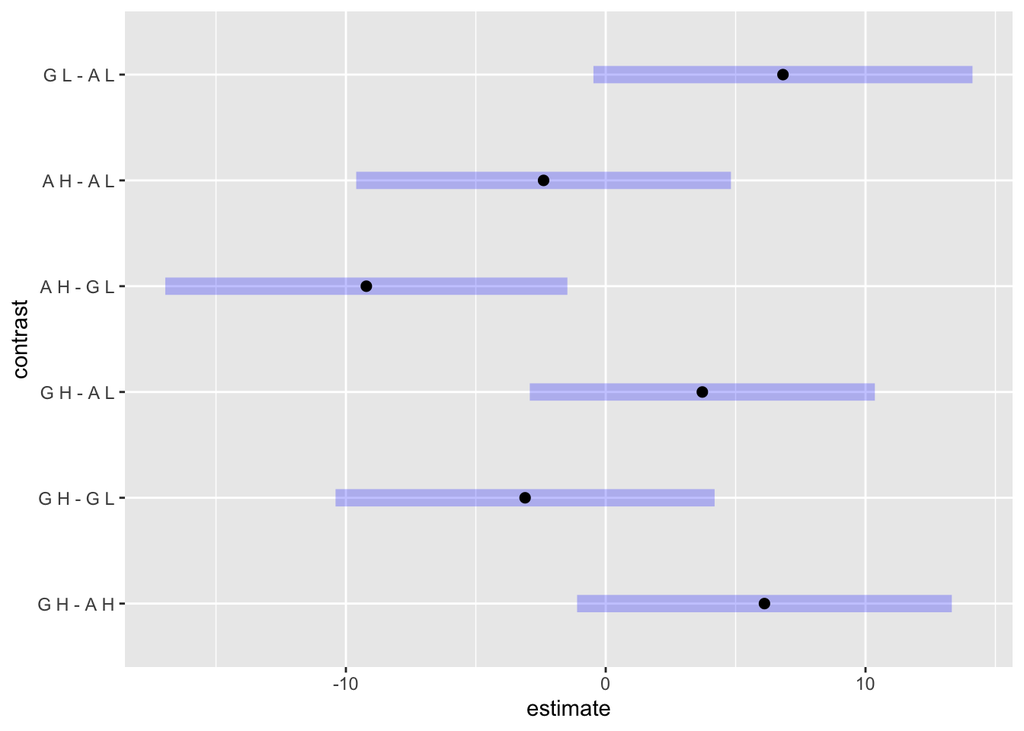

```r
plot(levels.contrast$contrasts)
```

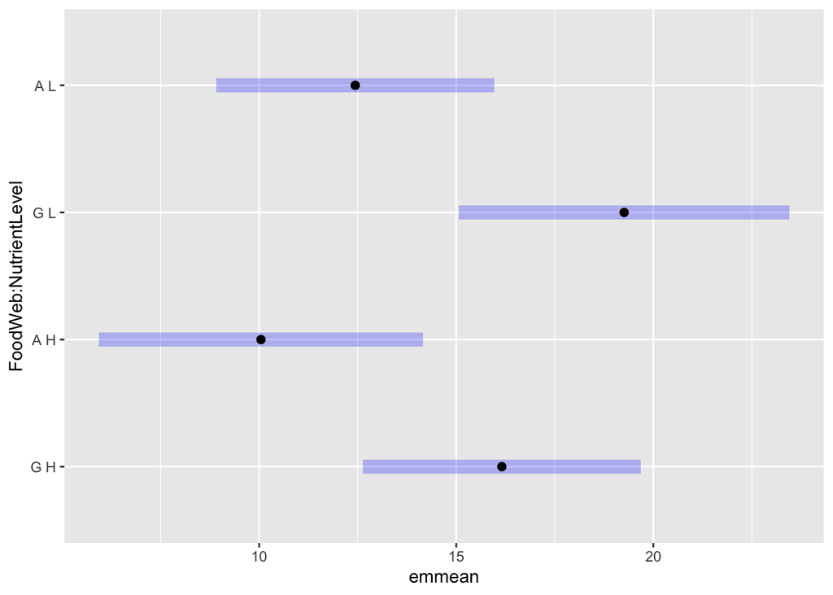

```r
plot(levels.contrast$emmeans)
```

So we want GH - AH: 6.11, adj. p = 0.1198 And we want GL- AL: 6.82 adj. p = 0.0734

*How do you interpret these results?* So I think what I’m seein’ is that, with low nutrients, grazers+algea do have an effect on phytoplankton diversity compared to Algae’s effect on phytoplankton diversity alone. With high nutrients, however, grazers do NOT effect phytoplankton diversity any differently than algea alone does.

I don’t know about phytoplankton ecology very much. Maybe algea outcompetes different phytoplanktons when there is too much nutrients and grazers can’t compensate for that? But with low nutrients, grazers can make enough headway on algea to make room for phytoplankton?

## 6)

*Repeat the same set of 4 contrasts but ask whether the P treatment is different from the G treatment*

NOTE: I feel like I’ve screwed something up here since these contrasts are more or less the same– I am a little confused about how to make a custom contrast when I am dealing with more than two categories, i.e. the notes had a treatment customization but I am not sure how to deal with NutrientLevel and FoodWeb levels at the same time.

P different from G at high:

```r
H_emmeans.P <- emmeans(richness.lm,
                        specs = pairwise  ~ FoodWeb|NutrientLevel,
                        at    = list(NutrientLevel = c("H")))
H_emmeans.P
```

```
## $emmeans
## NutrientLevel = H:
##  FoodWeb emmean   SE df lower.CL upper.CL
##  A        10.05 2.01 30     5.94     14.2
##  G        16.16 1.73 30    12.63     19.7
##  P         9.65 2.06 30     5.44     13.9
##
## Results are averaged over the levels of: Block
## Confidence level used: 0.95
##
## $contrasts
## NutrientLevel = H:
##  contrast estimate   SE df t.ratio p.value
##  A - G      -6.110 2.65 30  -2.304  0.0707
##  A - P       0.399 2.91 30   0.137  0.9897
##  G - P       6.509 2.69 30   2.421  0.0550
##
## Results are averaged over the levels of: Block
## P value adjustment: tukey method for comparing a family of 3 estimates
```

Kay, G and P are different in that P has less phytoplankton diversity than G, and there is a slightly significant difference between the two groups (adj. p= 0.05)

P different from G at low:

```r
L_emmeans.P <- emmeans(richness.lm,
                        specs = pairwise  ~ FoodWeb|NutrientLevel,
                        at    = list(NutrientLevel = c("L")))
L_emmeans.P
```

```
## $emmeans
## NutrientLevel = L:
##  FoodWeb emmean   SE df lower.CL upper.CL
##  A         12.4 1.73 30     8.91     16.0
##  G         19.3 2.05 30    15.07     23.5
##  P         17.2 2.26 30    12.61     21.8
##
## Results are averaged over the levels of: Block
## Confidence level used: 0.95
##
## $contrasts
## NutrientLevel = L:
##  contrast estimate   SE df t.ratio p.value
##  A - G       -6.82 2.68 30  -2.543  0.0421
##  A - P       -4.79 2.84 30  -1.683  0.2281
##  G - P        2.03 3.11 30   0.654  0.7917
##
## Results are averaged over the levels of: Block
## P value adjustment: tukey method for comparing a family of 3 estimates
```

At low, there is not that much of a difference.

P different from G averaging out the nutrients:

```r
avg.emmeans.P <- pairs(emmeans(richness.lm,"FoodWeb",
                        at = list(FoodWeb= c("G","P"))))
avg.emmeans.P
```

```
##  contrast estimate  SE df t.ratio p.value
##  G - P        4.27 2.1 30   2.033  0.0510
##
## Results are averaged over the levels of: NutrientLevel, Block
```

Okay averagng across the nutrient level and block, G and P have different phytoplankton diversity! Grazers have more. non-adj (?) p= 0.0510

Is the difference between P and G different between H and L (is G-P for the high nutrient treatments greater or smaller than G-P for the low nutrient treatments?)

```r
levels.contrast.P <- (emmeans(richness.lm,
                            specs = pairwise ~ FoodWeb*NutrientLevel,
                            at    = list(FoodWeb = c("G","P"))))
levels.contrast.P
```

```
## $emmeans
##  FoodWeb NutrientLevel emmean   SE df lower.CL upper.CL
##  G       H              16.16 1.73 30    12.63     19.7
##  P       H               9.65 2.06 30     5.44     13.9
##  G       L              19.26 2.05 30    15.07     23.5
##  P       L              17.23 2.26 30    12.61     21.8
##
## Results are averaged over the levels of: Block
## Confidence level used: 0.95
##
## $contrasts
##  contrast  estimate   SE df t.ratio p.value
##  G H - P H     6.51 2.69 30   2.421  0.0945
##  G H - G L    -3.10 2.68 30  -1.157  0.6580
##  G H - P L    -1.07 2.84 30  -0.376  0.9815
##  P H - G L    -9.61 2.95 30  -3.263  0.0139
##  P H - P L    -7.58 2.97 30  -2.553  0.0719
##  G L - P L     2.03 3.11 30   0.654  0.9134
##
## Results are averaged over the levels of: Block
## P value adjustment: tukey method for comparing a family of 4 estimates
```

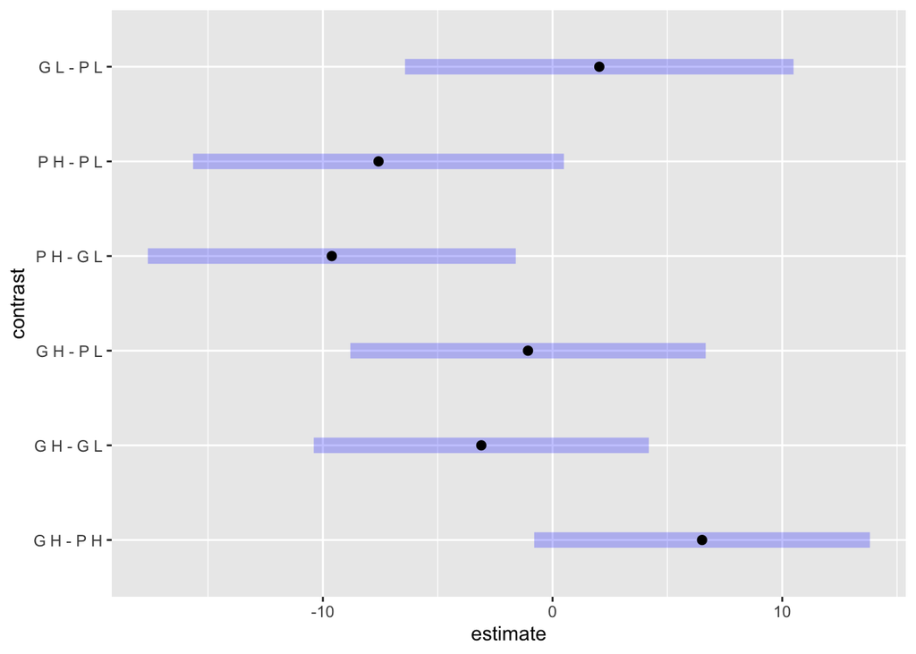

```r
plot(levels.contrast.P$contrasts)
```

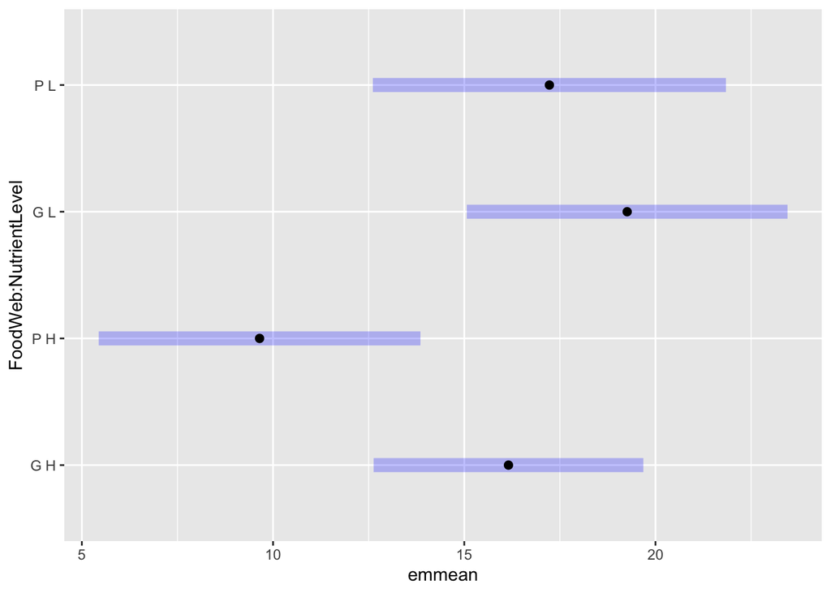

```r
plot(levels.contrast.P$emmeans)
```

G-P for High: 6.51 , adj. p value of 0.0945 G-P for Low: 2.03, adj. p value of 0.9134 I want to probably contrast these right?

*How do you interpret the results?*

OKAY. Here’s my shot. When averaging out nutrient levels, predators introduced to the system lower the phytoplankton diversity (probably by getting rid of them grazers).

Grazers influence phytoplankton diversity when nutrients are low. If a predator is there, there isn’t a huge effect but grazers give more diversity (GL-PL 2.03, adj. p= 0.9).

When nutrients are high, predators can really stink up the diversity, probably by taking out grazers. I have a feeling I need another contrast interaction to show how *much* they are stinking up the diversity.